# HW 6 -

Emulie Chhor

29/12/2022

# Question 1 - ChickWeight Data

## a) Plot the data

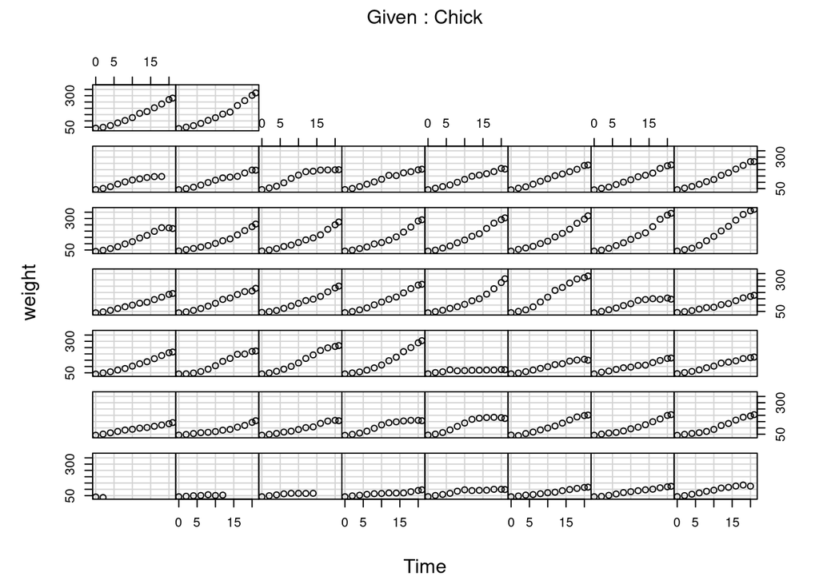

```r
coplot(weight ~ Time | Chick, data = ChickWeight, type='b', show.given = FALSE)
```

```r
# plot(weight~ Time, data = ChickWeight)
```

## b) Extract the data corresponding to the sixth chick.

1. Fit a linear model using time to predict weight. Check the residuals to check if the model fits well. If not, plot it using polynomials.

```r
chick6 <- ChickWeight[ChickWeight$Chick == 6, ]
model_chick6 <- lm(weight~Time, data = chick6)
summary(model_chick6)
```

```
##
## Call:
## lm(formula = weight ~ Time, data = chick6)
##
## Residuals:
##     Min      1Q  Median      3Q     Max
## -21.062  -8.953  -1.026  10.268  20.340
##
## Coefficients:
##             Estimate Std. Error t value Pr(>|t|)
## (Intercept)  44.1234     7.3514   6.002 0.000132 ***
## Time          6.3780     0.5722  11.147 5.83e-07 ***
## ---
## Signif. codes:  0 '***' 0.001 '**' 0.01 '*' 0.05 '.' 0.1 ' ' 1
##
## Residual standard error: 13.43 on 10 degrees of freedom
## Multiple R-squared:  0.9255, Adjusted R-squared:  0.9181
## F-statistic: 124.3 on 1 and 10 DF,  p-value: 5.825e-07
```

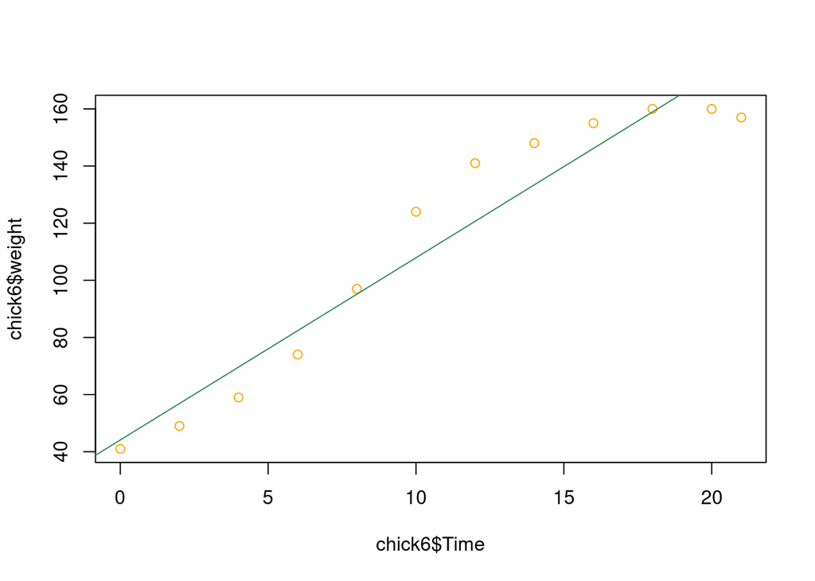

```r
# plotting the model
plot(chick6$Time, chick6$weight, col='orange')
abline(model_chick6, col='seagreen')
```

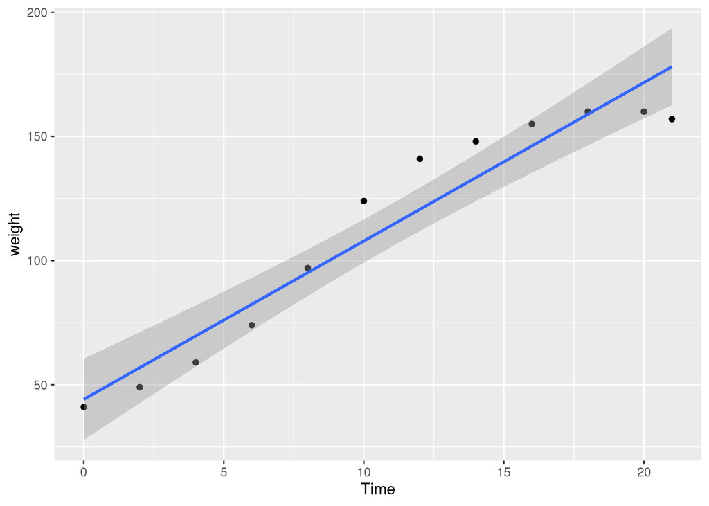

```r
ggplot(chick6, aes(x=Time, y=weight)) +
  geom_point() +
  geom_smooth(method = 'lm')
```

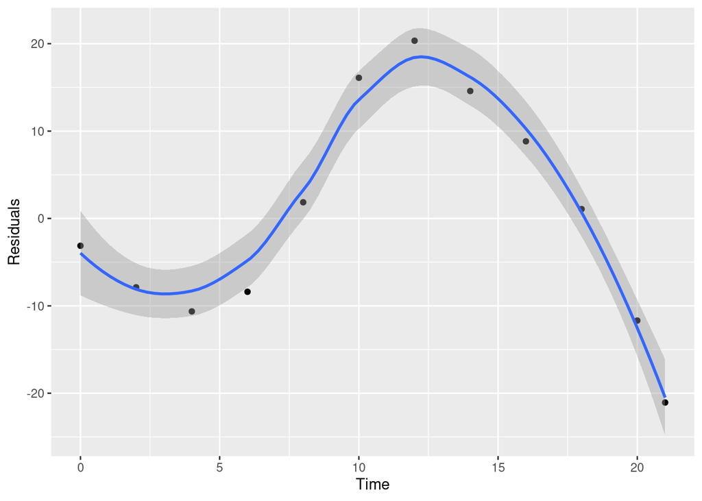

```r
# plotting the residuals
ggplot() +
  geom_point(aes(x=chick6$Time, y=residuals(model_chick6))) +
  geom_smooth(aes(x=chick6$Time, y=residuals(model_chick6))) +
  xlab("Time") + ylab("Residuals")
```

```r
# plot(chick6$Time, residuals(model_chick6), xlab = "Time", ylab = "Residuals")
# abline(h=0, col='gray')
```

By plotting the residual plot, we see that a simple linear model doesn’t fit well because the residuals seems correlated. We will try to fit a polynomial

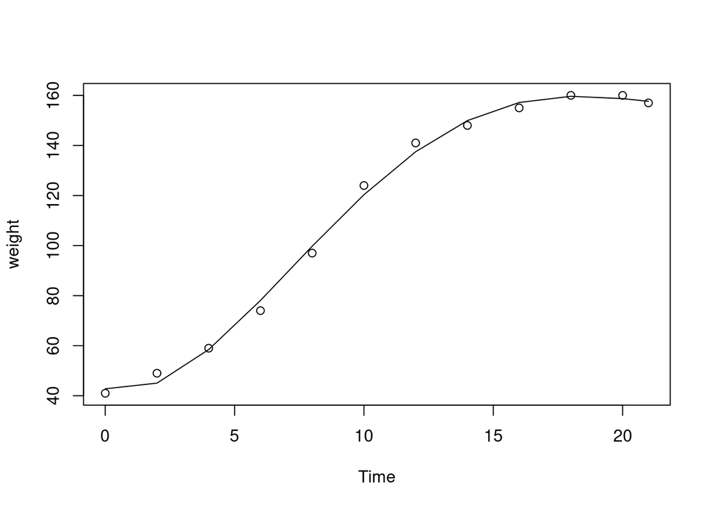

```r
# constructing polynomial model
model_poly <- lm(weight ~ Time + I(Time ^2) + I(Time ^3) + I(Time^4), data = chick6)
with(chick6, plot(Time, weight))
lines(chick6$Time, fitted(model_poly))
```

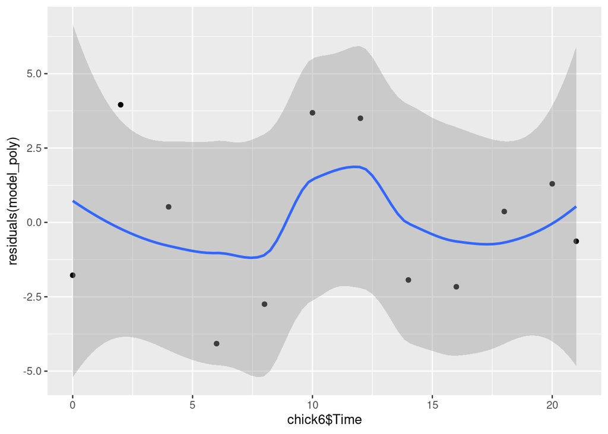

```r
# summary(model_poly)

# plotting the residuals
ggplot() +
  geom_point(aes(x=chick6$Time, y=residuals(model_poly))) +
  geom_smooth(aes(x=chick6$Time, y=residuals(model_poly)))
```

The polynomial model is a better fit than the simple linear regression model because the residuals don’t seem to be correlated

## c) Fit a linear model to predict weight from time (ignore chick and diet) using all the data

1. Fit a linear model using time to predict weight. Check the residuals to check if the model fits well. If not, plot it using polynomials.

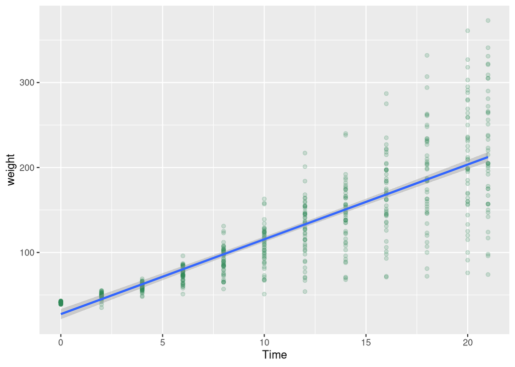

```r
# plotting linear regression
model_all_chicks <- lm(weight~Time, data = ChickWeight)
ggplot(ChickWeight, aes(x=Time, y=weight)) +
  geom_point(alpha = 0.2, col='seagreen') +
  geom_smooth(method = 'lm')
```

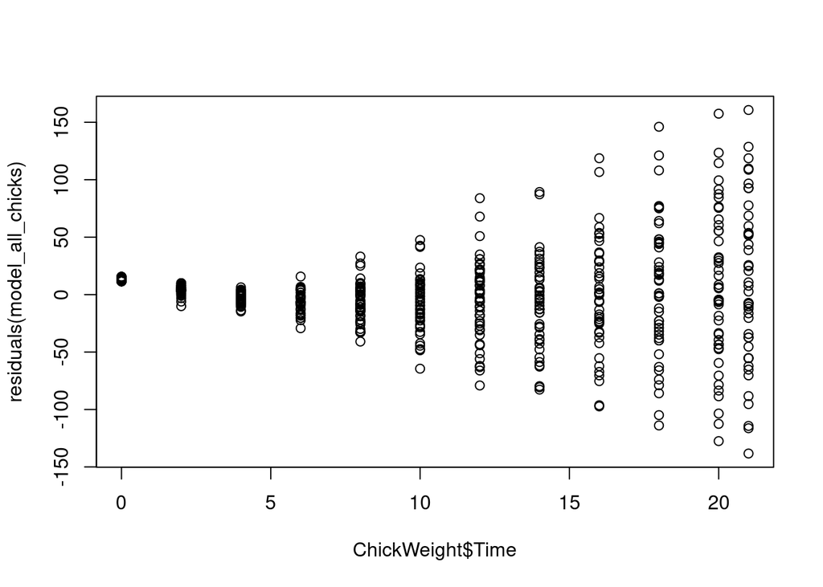

```r
# plotting residuals
plot(ChickWeight$Time, residuals(model_all_chicks))
```

It seems that the simple linear regression isn’t a good fit since the model violate the homodescacity hypothesis: the residuals keeps increasing and are therefore not constant. We will plot the data using a polynomial

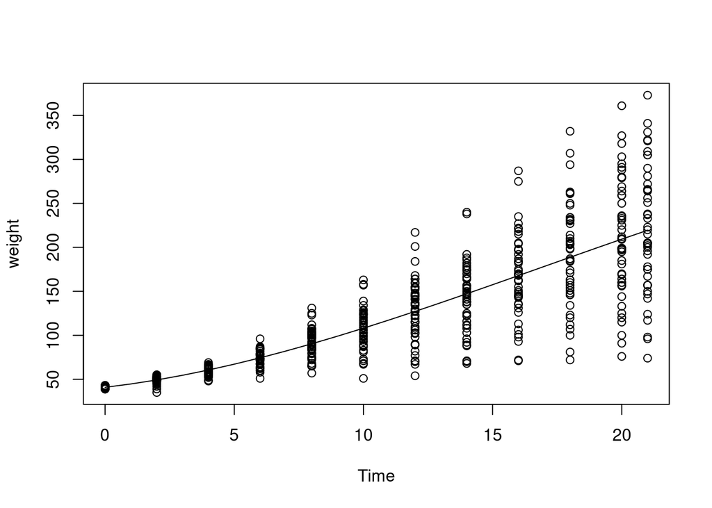

```r
# plot polynomial regression
model_all_chicks_poly <- lm(weight ~ Time + I(Time^2) + I(Time ^3), data = ChickWeight)
# model_all_chicks_poly <- lm(weight ~ Time + I(Time^2) , data = ChickWeight)
with(ChickWeight, plot(x=Time, y=weight))
lines(seq(0, max(ChickWeight$Time)),
      predict(model_all_chicks_poly, newdata = data.frame(Time = seq(0, max(ChickWeight$Time)))))
```

```r
# fitted(model_all_chicks_poly)
# predict(model_all_chicks_poly, newdata = data.frame(Time = seq(0, max(ChickWeight$Time))))
# summary(model_all_chicks_poly)

# plot residuals
```

## d) Repeat c) but include Diet variable (treat it as categorical variable) (TODO)

```r
model4 <- lm(weight~Time + I(Time^2) + factor(Diet), data = ChickWeight)
```

# Question 2 - Income

```r
x0 <- rep(1, 12)
x1 <- c(1,1,1,1,0,0,0,0,0,0,0,0)
x2 <- c(0,0,0,0,1,1,1,1,0,0,0,0)
x3 <- c(0,0,0,0,0,0,0,0,1,1,1,1)
Y <- c(33, 36, 35, 35, 31, 29, 31, 29, 37, 39, 36, 36)
X <- cbind(x0, x1, x2)
```

## a) Show that if we include all three of the covariates, the $X^TX$ is not invertible. Explain why

Since $X0=X1+X2+X3$, then the columns are linearly dependant which means that $det(X^TX) = 0$. Thus, the matrix is not invertible.

## b) Fit the model: $Y=\beta_0 + \beta_1 X_1 + \beta_2 X_2 + \epsilon$

```r
# model6 <- lm(Y~X-1)
model6 <- lm(Y~X)
tmp <- summary(model6)$coefficients
row.names(tmp) <- c("Intercept", "France", "Italy")
kable(tmp)
```

|  | Estimate | Std. Error | t value | Pr(>\|t\|) |
| --- | --- | --- | --- | --- |
| Intercept | 37.00 | 0.6400955 | 57.803877 | 0.0000000 |
| France | -2.25 | 0.9052317 | -2.485552 | 0.0346742 |
| Italy | -7.00 | 0.9052317 | -7.732827 | 0.0000290 |

## d) using the regression output, construct a 95 percent confidence interval for the mean income of France

The 95% confidence interval for France’s is given by the following formula:

$(\beta_0 + \beta_1) \pm t_{n-2}(0.025) \sqrt{Var(\beta_0 + \beta_1)}$

$Var(\beta_0 + \beta_1) = Var(\beta_0) + Var(\beta_1)+ 2Cov(\beta_0, \beta_1)$

$Cov(\beta_0, \beta_1)=\frac{1}{n-1} \sum{(x- \bar{x})(y-\bar{y})}$

```r
n <- nrow(ChickWeight)
beta0 <- summary(model6)$coefficients[1,1]
beta1 <- summary(model6)$coefficients[2,1]
std_beta0 <- summary(model6)$coefficients[1,2]
std_beta1 <- summary(model6)$coefficients[2,2]
cov_b0_b1 <- 1/(n-1) *sum((X - mean(X))*(Y- mean(Y)))
std_b0_b1 <- sqrt(std_beta0^2 + std_beta1^2 + 2* cov_b0_b1)


left <- (beta0 + beta1) - qt(0.025, df=n-2, lower.tail = FALSE) * std_b0_b1
right <- (beta0 + beta1) + qt(0.025, df=n-2, lower.tail = FALSE) * std_b0_b1
```

The 95% confidence interval for France income is (32.61, 36.89)

# Question 3 - birthwt

## a) Plot the data using pairs command

```r
help("birthwt")
names(birthwt)
```

```
##  [1] "low"   "age"   "lwt"   "race"  "smoke" "ptl"   "ht"    "ui"    "ftv"
## [10] "bwt"
```

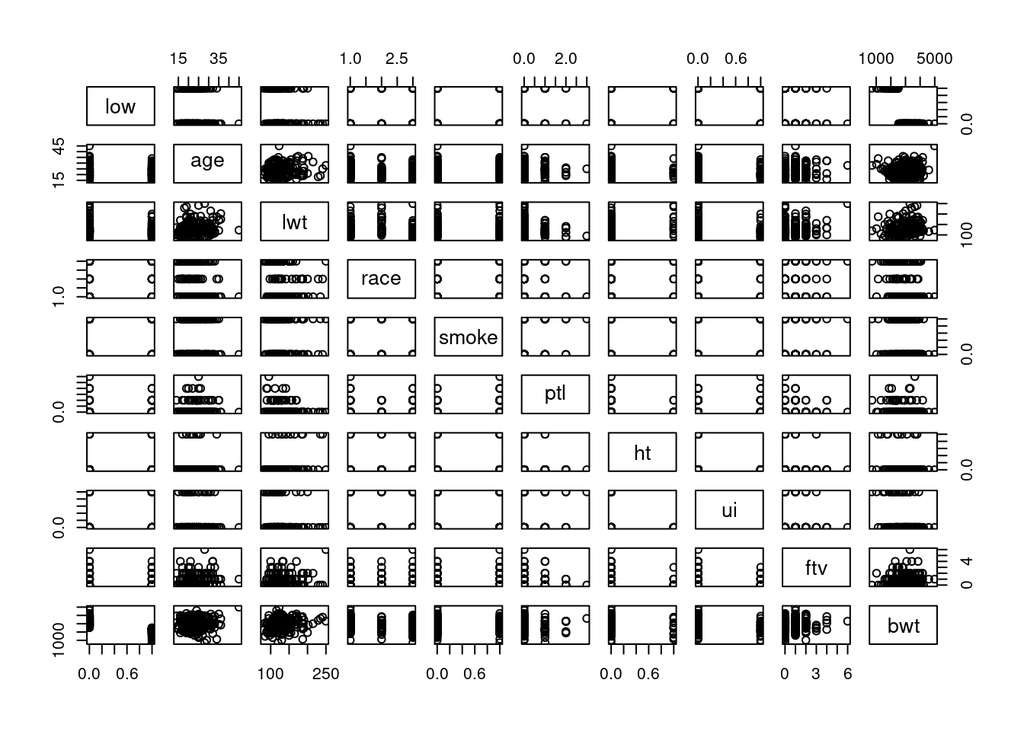

```r
pairs(birthwt)
```

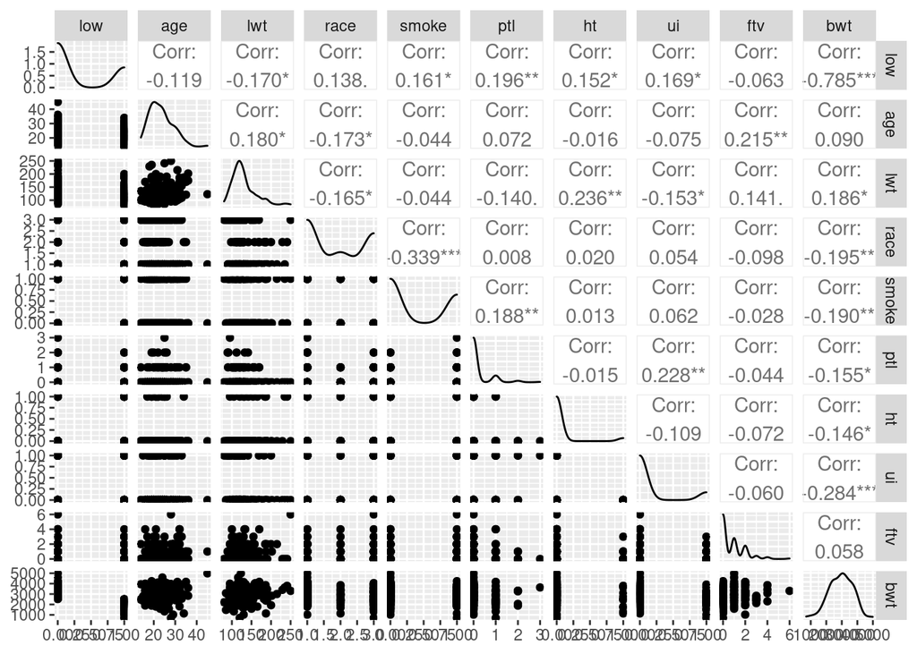

```r
GGally::ggpairs(birthwt)
```

## b) Fit a multiple regression model. Summarize the fitted model

```r
names(birthwt)
```

```
##  [1] "low"   "age"   "lwt"   "race"  "smoke" "ptl"   "ht"    "ui"    "ftv"
## [10] "bwt"
```

```r
model7 <- lm(bwt~age+lwt+factor(race)+factor(smoke)+ptl+factor(ht)+factor(ui)+ftv, data = birthwt)
tmp <- summary(model7)
kable(tmp$coefficients)
```

|  | Estimate | Std. Error | t value | Pr(>\|t\|) |
| --- | --- | --- | --- | --- |
| (Intercept) | 2927.961937 | 312.904261 | 9.3573732 | 0.0000000 |
| age | -3.569934 | 9.620231 | -0.3710861 | 0.7110122 |
| lwt | 4.354013 | 1.735586 | 2.5086706 | 0.0130073 |
| factor(race)2 | -488.427538 | 149.984535 | -3.2565193 | 0.0013491 |
| factor(race)3 | -355.077107 | 114.753323 | -3.0942643 | 0.0022899 |
| factor(smoke)1 | -352.044534 | 106.476420 | -3.3063145 | 0.0011423 |
| ptl | -48.402034 | 101.971598 | -0.4746619 | 0.6356065 |
| factor(ht)1 | -592.827444 | 202.321160 | -2.9301307 | 0.0038298 |
| factor(ui)1 | -516.080977 | 138.885352 | -3.7158777 | 0.0002705 |
| ftv | -14.058054 | 46.468036 | -0.3025317 | 0.7625980 |

## c) Summarize your conclusions. Summarize your fitted model and interpret the coefficients